# AWS Solution Architect - Networking - Les bases

AdrienSIEG

02/04/2020

## Qu’est-ce qu’un réseau ?

Un **réseau** est un ensemble de machines qui sont reliés ensembles. Machines = PC, automates, imprimantes, … Pour communiquer entre elles, elles doivent avoir **une adresse** (cf. La Poste)

## Qu’est-ce qu’une adresse IP ?

- L’adresse IP sert à quoi ? Une partie sert à définir l’**adresse de la machine dans un réseau** et une autre à définir **l’adresse du réseau dans lequel on se trouve**. Mais quel partie ? Pour le savoir, il faut le **masque de sous-réseau**.

Une **adresse IP** se compose de **deux parties** :

Les **bits d’ordre supérieur**, ou les bits les plus à gauche, spécifient le composant d’**adresse réseau (ID réseau) de l’adresse**. Les **bits d’ordre inférieur**, ou le plus à droite, spécifient le composant d’**adresse hôte (ID hôte) de l’adresse**.

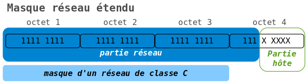

- Constitué de **4 octets de 8 bits** –> soit **32 bits**
- Valeur d’un octet varie entre **0** et **255**
- Exemple d’adresse IP : **192.168.0.1**

## Qu’est-ce qu’un masque de sous-réseau ?

- Un **masque de sous-réseau** ressemble un peu à une **adresse IP** dans la forme, mais **chaque octet ne peut prendre que certaines valeurs**.
- Un **masque de sous-réseau** associé à une **adresses IP** définit une **plage d’adresses** et vont constituer un **réseau**. C’est donc **le masque qui va définir avec qui on peut communiquer**.

Prenons une **adresse IP** quelconque : **42.51.82.3** Associons à cette adresse **un masque**, par exemple **255.0.0.0** Ce **masque** va définir **quelle partie de l’adresse IP identifie le réseau** (cette partie est appellée **network ID**) et **quelle partie identifie l’hôte sur le réseau** (**host ID**).

Un **masque de sous-réseau** définit donc **la plage d’adresses IP** avec laquelle **une carte réseau** peut communiquer directement. Pour **communiquer avec des adresses IP extérieures** à cette plage, elle doit passer par une **passerelle par défaut**.

Règles

On **ne peut pas mélanger les zéros** et les **autres valeurs**. En somme, tous les 255 doivent être à gauche et les zéros à droite. Pourquoi ? Parce que **dans une adresse IP**, c’est la **partie gauche** qui correspond à **l’identité du réseau**, et **la partie droite** qui correspond à **l’identité de l’hôte**. Ces exemples de masques sont donc invalides : 255.0.0.255, 255.255.0.255, 0.0.0.255, …

- Combien de machines on peut mettre sur un sous-réseau ? Cela est défini par un **masque de sous-réseau**.
- On prend la **partie haute du masque de sous réseau** c’est-à-dire la série de zéro qui est à la fin du réseau.
- Ici il est sur un octet et comme un octet peut être codé entre $0$ et $255$ (soit 256 nombres possibles) –> on peut coder 256 adresses (il y a cependant deux adresses qui sont réservées - celle finissant par $0$ et celle finissant par $255$). Il y a **254 adresses disponibles/utilisables**.
- Celle finissant par $0$ : c’est l’adresse du réseau qui permet d’identifier le réseau
- **192.168.0.255** est l’adresse de Broadcast ou de diffusion - qui permet à envoyer un message à toutes les machines du réseau. Toutes les machines connectées au réseau **192.168.0.0** recevront le message.
- La première adresse est **192.168.0.1** que j’ai le droit d’utiliser (après l’adresse réseau) et la dernière est **192.168.0.254**

## Qu’est-ce que le subnetting?

Le **subnetting** est une technique qui consiste à **diviser un réseau plus large en plusieurs sous-réseaux**.Le subnetting est l’action de créer des sous-réseaux.Comment ? en **personnalisant les masques**.

Par exemple, admettons un réseau de 1000 ordinateurs. La gestion d’un tel réseau ne doit pas être évidente. Grâce au subnetting, on peut par exemple diviser ce grand réseau en 10 réseaux de 100 ordinateurs chacun.

Pour personnaliser les masques de sous-réseau, il faut **emprunter des bits de la partie host (client)** de notre **adresse IP**.

- **host ID** signifie **identité de l’hôte** et **network ID** signifie **identité du réseau**.

**Plus on “monte” dans les masques (c’est à dire qu’on passe de 255.0.0.0 à 255.255.0.0, de 255.255.0.0 à 255.255.255.0, …), plus le network ID devient grand : il gagne un octet de plus à chaque fois, et le host ID en perd un.**

- On remarque - pour le masque de sous-réseau - qu’on a une suite de $1$ ininterrompu - 255 est le nombre le plus grand qu’on puisse coder sur un octet. Un masque de sous-réseau doit avoir QUE des uns à gauche et QUE des zéros à droite.
- Plus vous mettez de $1$ à gauche (et donc moins vous mettez de $0$ à droite), plus vous pouvez créer des sous-réseaux différents. L’inverse permettra de mettre plus de machines.
- **Faire du subnetting, c’est subdiviser un réseau en plusieurs sous-réseaux, diminuer le nombre d’adresses IP par sous-réseau.** Plusieurs manières pour subnetter :
  - En partant du nombre de sous-réseaux désirés;
  - En partant du nombre d’adresses IP désirées par sous-réseau;
  - En combinant les deux, c’est-à-dire en prenant en compte le nombre de sous-réseaux désirés et le nombre d’adresses IP désirées par sous-réseau

## Qu’est-ce qu’une classe ?

| Classe d’adresse | Plage des valeurs du premier octet (décimales) | Portions réseau (N) et hôte (H) des adresses IP | Masque de sous-réseau par défaut (décimal et binaire) | Nombre de réseaux et d’hôtes possibles par réseau |
| --- | --- | --- | --- | --- |
| A | 1–127 | N.H.H.H | 255.0.0.0 | $2^{7} = 128$ réseaux $2^{24} - 2 = 16,777,214$ hôtes par réseau |
| B | 128–191 | N.N.H.H | 255.255.0.0 | $2^{14} = 16,384$ réseaux $2^{16} - 2 = 65,534$ hôtes par réseau |
| C | 192–223 | N.N.N.H | 255.255.255.0 | $2^{21} = 2,097,152$ réseaux $2^{8} - 2 = 254$ hôtes par réseau |
| D | 224–239 | Non utilisé pour l’adressage d’hôtes |  |  |
| E | 240–255 | Non utilisé pour l’adressage d’hôtes |  |  |

- Notion de classes est obsolète
- **Classe A** : Toute petite partie pour le sous-réseau mais possibilités de mettre beaucoup de machines (qu’un petit réseau avec beaucoup de machines que l’on peut mettre sur 3 octets !)
- **Classe B** : Autant de machines que de possibilités de créer de sous-réseaux. On peut mettre des machines sur 2 octets
- **Classe C**: Masque de sous-réseau sur 3 octets ce qui fait qu’on peut diviser en beaucoup de sous réseaux mais qu’on ne peut pas mettre beaucoup de machines sur ces sous-réseaux.

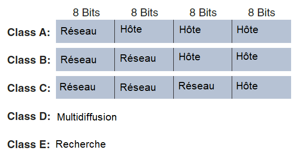

## Adressage IP privé et public ?

Les adresses IPv4 sont dites **publiques** si elles sont **enregistrées** et **routables** sur **Internet**, elles sont donc **uniques mondialement**. À l’inverse, **les adresses privées** ne sont **utilisables que dans un réseau local**, et ne doivent être **uniques que dans ce réseau**. La traduction d’adresse réseau [NAT = Network ], réalisée notamment par les box internet, transforme des adresses privées en adresses publiques et permet d’accéder à Internet à partir d’un poste du réseau privé.

La RFC 1918, “Address Allocation for Private Internets”, a réduit la demande d’adresses IP en réservant les adresses suivantes pour utilisation dans **les réseaux Internet privés** :

- Classe A : 10.0.0.0.0/8 (10.0.0.0.0-10.255.255.255.255)
- Classe B : 172.16.0.0.0/12 (172.16.0.0.0-172.31.255.255)
- Classe C : 192.168.0.0.0/16 (192.168.0.0.0-192.168.255.255)

Si vous voulez effectuer l’adressage d’un **intranet non public**, ces adresses privées sont normalement utilisées à la place des adresses publiques uniques au monde (i.e. sur Internet).

Cela vous offre une flexibilité dans la conception de votre adressage. Toute organisation peut profiter pleinement d’une adresse réseau de classe A complète (10.0.0.0.0/8).

La transmission du trafic vers l’Internet public **nécessite une conversion en une adresse publique** à l’aide de la **technique NAT (Network Address Translation)**.

Mais en surchargeant une adresse Internet-routable avec de nombreuses adresses privées, une entreprise n’a besoin que d’une poignée d’adresses publiques.

## Qu’est-ce que CIDR?

Supposons qu’on vous donne l’adresse réseau **192.168.1.0** avec le **masque de sous-réseau** par défaut **255.255.255.0**.

L’**adresse réseau** et le **masque de sous-réseau** peuvent être écrits comme **192.168.1.0.0/24**. Le **/24** représente le **masque de sous-réseau** dans une notation plus courte et signifie que **les 24 premiers bits sont des bits réseau**.

## Qu’est-ce que le SuperNetting ?

UN SuperNetwork ou supernet est un protocole Internet (IP) qui est formée, **à des fins de routage**, de la **combinaison de deux ou plusieurs réseaux (ou sous - réseaux )** dans un réseau plus grand. Le nouveau préfixe de routage pour le réseau combiné représente les réseaux constitutifs dans une seule table de routage entrée. Procédé de formation d’un supernet est appelé supernetting, agrégation préfixe, l’agrégation de la route, ou un résumé de l’itinéraire.

## Ex – Déterminer l’adresse du réseau

### Enoncé

[output not shown]

### 1. Déterminer l’adresse du réseau ?

**A. On convertit l’adresse IP en binaire**

| $2^7$ | $2^6$ | $2^5$ | $2^4$ | $2^3$ | $2^2$ | $2^1$ | $2^0$ |
| --- | --- | --- | --- | --- | --- | --- | --- |
| 128 | 64 | 32 | 16 | 8 | 4 | 2 | 1 |
| 1 | 0 | 1 | 0 | 1 | 1 | 0 | 0 |
| 1 | 0 | 0 | 0 | 0 | 0 | 0 | 0 |
| 0 | 0 | 0 | 0 | 1 | 0 | 1 | 0 |
| 0 | 0 | 0 | 0 | 0 | 1 | 0 | 1 |

Adresse IP en binaire :

| Adresse IP en décimal | 172.128.10.5 |
| --- | --- |
| Adresse IP en binaire | 1010 1100. 1000 0000. 0000 1010. 0000 0101 |

**B. On convertit le masque de sous-réseau en binaire**

| $2^7$ | $2^6$ | $2^5$ | $2^4$ | $2^3$ | $2^2$ | $2^1$ | $2^0$ |
| --- | --- | --- | --- | --- | --- | --- | --- |
| 128 | 64 | 32 | 16 | 8 | 4 | 2 | 1 |
| 1 | 1 | 1 | 1 | 1 | 1 | 1 | 1 |
| 1 | 1 | 1 | 1 | 1 | 1 | 1 | 1 |
| 1 | 1 | 0 | 0 | 0 | 0 | 0 | 0 |
| 0 | 0 | 0 | 0 | 0 | 0 | 0 | 0 |

[output not shown]

**C. Méthode du ET logique**

| Adresse IP en binaire | 1010 1100. 1000 0000. 0000 1010. 0000 0101 |
| --- | --- |
| Masque de sous-réseau en binaire | 1111 1111. 1111 1111. 1100 0000. 0000 0000 |
| Résultat | 1010 1100. 1000 0000. 0000 0000. 0000 0000 |

Ce qui donne en binaire : 172.128.0.0

### 2. Déterminer le nombre d’adresses utilisables ?

Pour déterminer le nombre d’adresses utilisables sur notre réseau, il faut prendre notre masque de sous-réseau.

[output not shown]

- La **partie haute** est le groupe de $0$ qui permet de coder les adresses de mes machines. Elle s’étend sur 14 bits - Combien de nombre peut on coder sur 14 bits ?

Le plus grand nombre c’est **11 1111 1111 1111** qui vaut **16 383**

| $2^{13}$ | $2^{12}$ | $2^{11}$ | $2^{10}$ | $2^{9}$ | $2^{8}$ | $2^{7}$ | $2^{6}$ | $2^{5}$ | $2^{4}$ | $2^{3}$ | $2^{2}$ | $2^{1}$ | $2^{0}$ |
| --- | --- | --- | --- | --- | --- | --- | --- | --- | --- | --- | --- | --- | --- |
| 1 | 1 | 1 | 1 | 1 | 1 | 1 | 1 | 1 | 1 | 1 | 1 | 1 | 1 |

$2^{13}$ + $2^{12}$ + $2^{11}$ + $2^{10}$ + $2^{9}$ + $2^{8}$ + $2^{7}$ + $2^{6}$ + $2^{5}$ + $2^{4}$ + $2^{3}$ + $2^{2}$ + $2^{1}$ + $2^{0}$ = $8192$ + $4096$ + $2048$ + $1024$ + $512$ + $256$ + $128$ + $64$ + $32$ + $16$ + $8$ + $4$ + $2$ + $1$

Donc on peut coder $16383$ - $0$ + $1$ = $16 384$ - $2$ (les 2 adresses non utilisables : l’adresse du réseau et l’adresse du broadcast)

### 3. Determiner l’adresse de broadcast du réseau ?

- Reprendre l’adresse du réseau (au dessus c’était simple - ici compliqué)
- La partie haute de notre réseaux ce sont les 14 derniers bits donc il faut se concentrer ici sur les 14 derniers chiffres

| Adresse du réseau en décimal | 172.128.0.0 |
| --- | --- |
| Résultat | 1010 1100. 1000 0000. 00**00 0000. 0000 0000** |

- Ces derniers chiffres au lieu qui soit égale à zéro on les passe à $1$ 1010 1100. 1000 0000. 00**11 1111. 1111 1111**
- Puis on converti cette adresse en décimale

| Adresse du broadcast réseau en binaire | 1010 1100. 1000 0000. 00**11 1111. 1111 1111** |
| --- | --- |
| Adresse du broadcast réseau en décimale | 172. 128. 63. 255 |

et cet octet **0011 1111** ça donne :

$2^{5}$ + $2^{4}$ + $2^{3}$ + $2^{2}$ + $2^{1}$ + $2^{0}$ = $32$ + $16$ + $8$ + $4$ + $2$ + $1$ = $63$

### 4. Donner la plage adressable du réseau ?

Plage d’adresse adressable :

- On prend l’adresse réseau et on fait plus 1 (**à l’adresse réseau en binaire**). Attention pas à l’adresse elle-même

| Adresse du réseau en décimal | 172.128.0.0 |
| --- | --- |
| Adresse du réseau en binaire | 1010 1100. 1000 0000. 0000 0000. 0000 0000 |
| Adresse du réseau en binaire + 1 à la fin | 1010 1100. 1000 0000. 0000 0000. 0000 0001 |
| Adresse du réseau en décimal + 1 à la fin | 172.128.0.1 |

- On prend l’adresse réseau et on fait plus 1 (**à l’adresse réseau en binaire**). Attention pas à l’adresse elle-même

[output not shown]

La plage adressable est donc les adresses entre **172.128.0.1** et **172. 128. 63. 254**

## Ex – Déterminer la partie Host ID et Machine ID d’une adresse IP?

- Adresse IP: **192.168.0.1**
- Masque de sous-réseau: **255.255.255.0**

Une **adresse IP** identifie à la fois **une machine** et **le réseau** sur lequel elle est connectée. Pour **distinguer la partie de l’adresse** qui correspond au réseau de celle qui correspond à **la machine**, nous aurons besoin du masque de sous-réseau.

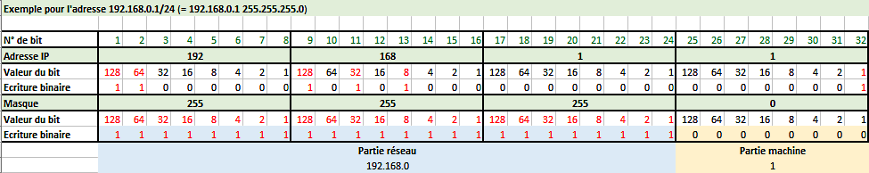

La partie réseau est 192.168.0 (sur 3 octets, en bleu), la partie machine étant 1 (1 octet, en jaune)

## Ex – En partant du nombre de sous-réseaux désirés

Sous-réseautage en quatre étapes

- **Étape 1**. Déterminez le nombre de bits à emprunter, en fonction des exigences de l’hôte.
- **Étape 2**. Déterminez le nouveau masque de sous-réseau.
- **Étape 3**. Déterminez le multiplicateur de sous-réseau.
- **Étape 4**. Énumérez les sous-réseaux, y compris l’adresse du sous-réseau, la plage d’hôtes et l’adresse de diffusion.

$S$ est le nombre de sous-réseaux désirés $n$ est le nombre de bits devant être masqués

**Masquer** signifie le mettre à $1$ pour les besoins du subnetting - emprunter des bits de la partie hôte pour créer des sous-réseaux.

**Exemple de subnetting**:

Considérons le réseau **40.0.0.0** Nous voulons le diviser en **20 sous-réseaux**. Déterminons **le nombre de bits à masquer** pour obtenir **un masque de sous-réseau personnalisé**, qui devra être appliqué à tous les hôtes.

### Étape 1. Déterminez le nombre de bits à emprunter, en fonction des exigences de l’hôte

On a suffisamment de réseaux en masquant **5 bits**. Mais attention, quand vous avez trop d’adresses IP par sous-réseau, vous devriez empêcher l’assignation des adresses inutilisées. C’est une question de sécurité, pour empêcher qu’un intrus puisse s’octroyer une adresse IP libre.

On ne peut pas mélanger les $1$ et les $0$, tous les $1$ doivent être à **gauche**, et les $0$ à **droite**. Cela veut dire le masquage se fait de la gauche vers la droite.

### Étape 2. Déterminez le nouveau masque de sous-réseau

$s$ = subnet ; $h$ = host

| Masque de sous-réseau à créer | ssssssss | ssssshhh | hhhhhhhh | hhhhhhhh | hhhhhhhh |
| --- | --- | --- | --- | --- | --- |
| … traduction | ssssssss | ssssshhh | hhhhhhhh | hhhhhhhh | hhhhhhhh |
| … conversion en Bit | 1111 1111 | 1111 1000 | 0000 0000 | 0000 0000 | 0000 0000 |

### Étape 3. Déterminez le multiplicateur de sous-réseau

Maintenant, définir les limites de chaque sous-réseau, sinon ça ne va pas être très utile –> nous en avons 31.

Pour **calculer les plages**, il faut **retrancher le nombre calculé du nouveau masque de sous-réseau** à $256$ ($=255 -0 +1$)

Ce nombre est $248$, $256 - 248$ = $8$. Donc **nos sous-réseaux seront séparés par un intervalle** de $8$.

### Étape 4. Énumérez les sous-réseaux, y compris l’adresse du sous-réseau, la plage d’hôtes et l’adresse de diffusion.

- La **dernière adresse d’un sous-réseau** donné est toujours égale à l’**adresse de l’identité du prochain sous-réseau moins 1** Notre premier sous-réseau est 40.0.0.0. La première adresse IP adressable (pouvant être donnée à un hôte) est donc **40.0.0.1** et la dernière… **40.7.255.254**

La **dernière adresse dans un réseau** est réservée pour la **diffusion dite de broadcast**.

| Ordinal | Adresse du sous-réseau | Première adresse IP d’hôte | Dernière adresse IP d’hôte |
| --- | --- | --- | --- |
| 1er | 40.0.0.0 | 40.0.0.1 | 40.7.255.254 |
| 2ème | 40.8.0.0 | 40.8.0.1 | 40.15.255.254 |
| 3ème | 40.16.0.0 | 40.16.0.1 | 40.23.255.254 |
| 4ème | 40.24.0.0 | 40.24.0.1 | 40.31.255.254 |
| 5ème | 40.32.0.0 | 40.32.0.1 | 40.39.255.254 |
| … | … | … | … |
| 31ème | 40.240.0.0 | 40.240.0.1 | 40.247.255.254 |

## Ex – À partir du nombre d’adresses d’hôtes désirées

$S = 2^n - 2$

$S$ correspond au nombre d’hôtes désiré par sous-réseau

- Réseau **158.37.0.0.**
- Nous voulons **1800** hôtes par sous-réseau. Déterminons n :

$2^{10} - 2 = 1022 < 1800 < 2^{11} - 2 = 2046$

$n$ vaut donc $11$

$11$ bits doivent être **libres pour les hôtes**

Ce qui signifie que **11 bits doivent valoir 0**. Comme il y a **32 bits par masque**, pour connaître le nombre de bits devant valoir 1, on fait $32 - 11 = 21$.

Notre nouveau masque doit donc comporter $21$ bits allumés : **11111111 . 11111111 . 11111000 . 00000000.**

Ce qui nous donne en décimal **255.255.248.0.**

L’intervalle entre chaque sous-réseau est de $256 - 248 = 8$

[output not shown]

## Ex – CIDR & subnetting - basique

Étant donné le préfixe **192.168.1.0/24**, quelle devrait être la longueur du masque de sous-réseau autorisant jusqu’à 9 sous-réseaux?

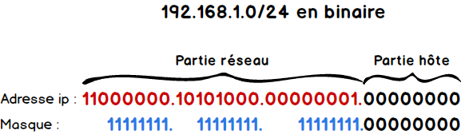

Afin de créer $9$ sous-réseaux, nous devons **étendre la longueur du masque de 4 bits**, ce qui permet d’utiliser jusqu’à $2^4 = 16$ sous-réseaux.

Donc, le résultat est: **192.168.1.0/28** (soit **192.168.1.0** et **255.255.255.240**).

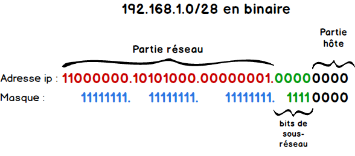

## Ex – CIDR & écriture - basique

Ecrire l’adresse IP **222.1.1.20** avec le masque **255.255.255.192** en notation CIDR ?

192 = 11000000 en binaire, ce qui signifie que **2 bits de cet octet sont utilisés pour le Subnetting**. Donc 24 + 2 = *26*

**222.1.1.20/26**

## Ex – CIDR & appartenance au même réseau

**Si vous voulez créer des sous-réseaux (en particulier des sous-réseaux flexibles), il ne suffit pas de simplement attacher le même suffixe à l’adresse IP.**

**192.168.200.5/30** et **192.168.200.9/30** n’appartiennent pas au même réseau

| Adresse IP | 192 | 168 | 200 |
| --- | --- | --- | --- |
| Adresse IP (en binaire) | 11000000 | 10101000 | 11001000 |
| Signification masque /30 | 11111111 | 11111111 | 11111111 |
| Méthode de AND-ing | 11000000 | 10101000 | 11001000 |
| Partie réseau | 192 | 168 | 200 |

Tandis que…

[output not shown]

Les deux adresses ne sont donc pas dans le même réseau. Elles l’auraient été si la deuxième adresse avait été **192.168.200.200.6/30**

## Ex – CIDR & Supernetting

Supposons qu’une entreprise possède **trois sites** et **trois réseaux** et leurs **routeurs correspondants**. Il serait logique, également dans le sens de la table de routage, d’en faire un supernet.

Les trois réseaux ont les adresses **192.168.43.0**, **192.168.44.0** et **192.168.45.0** (les masques de sous-réseau possibles à côté des adresses IP des réseaux sont pertinents dans ce contexte).

Nous les comparons d’abord en notation binaire et n’utilisons que les chiffres que les trois adresses ont en commun, de gauche à droite : à partir de la première différence, tous les autres chiffres sont mis à zéro.

| Adresse IP 1 (en décimal) | 192 | 168 | 43 | 0 |
| --- | --- | --- | --- | --- |
| Adresse IP 1 (en binaire) | **1100 0000** | **1010 1000** | **0010 1**011 | 0000 0000 |
| Adresse IP 2 (en décimal) | 192 | 168 | 44 | 0 |
| Adresse IP 2 (en binaire) | **1100 0000** | **1010 1000** | **0010 1**100 | 0000 0000 |
| Adresse IP 3 (en décimal) | 192 | 168 | 45 | 0 |
| Adresse IP 3 (en binaire) | **1100 0000** | **1010 1000** | **0010 1**101 | 0000 0000 |
| **Supernetting** | **1100 0000** | **1010 1000** | **0010 1**000 | 0000 0000 |
| **Supernet** | **192** | **168** | **40** | **0** |

L’adresse réseau du supernet est donc **192.168.40.0**. Pour déterminer le masque de sous-réseau correspondant qui appartient à ce réseau, vous comptez les emplacements (bits) qui ont conduit à la nouvelle adresse IP. Dans notre exemple, ce sont 21 bits : **192.168.40.0/21.**

https://coursreseaux.com/adressage-ipv4-prive-public-classes-sous-reseautage-vlsm/

## Ex – CIDR & A quoi sert le Supernetting?

Le **surnetting** est une technique qui consiste a créer **une « agrégation » de plusieurs réseaux** d’une **classe donnée** afin d’obtenir un **nombre plus importants d’adresses disponibles.**

Supposons que nous avons une adresse de **Classe C** - ce qui veut dire - avec les caractéristiques suivantes:

| Nb bits du « netid » | Nb bits du « hostid » | Masque | nb d’hôtes |
| --- | --- | --- | --- |
| 24 | 8 | 255.255.255.0 | 254 |

Supposons qu’on souhaite obtenir un réseau contenant **plus d’adresses que ne peut nous en fournir une classe C** ($400$ adresses par exemple) - ce qui est impossible car $254 < 400$

On serait alors obligé de prendre directement une adresse dans **une classe B**. Or, une classe B nous propose :

$2^{16} - 2 = 65534$ adresses disponibles ($32$ bits - $16$ bits de réseaux = $16$ bits d’hosts)

Soit un gâchis de $65534 – 400 = 65134$ adresses

Devant ce constat, une 2ème solution s’impose : **créer un sur-réseau de classe C** Nous allons donc utiliser une partie des **bits réservés au « netid »** pour les dédier au **« hostid »** - on crée une classe entre la classe C et B

On souhaite créer un réseau ayant les caractéristiques suivantes :

- **400** adresses minimum
- Adresse du réseau : **195.170.206.0**

A - Quelle est la puissance de 2 dont le résultat est supérieur et le plus proche de 400 ? $2^8 = 256 < 400 < 2^9 = 512$

B - Combien de bits minimum seront-ils donc nécessaires pour numéroter 400 ces postes ? $9$ bits

C - Quel sera donc le masque de sur-réseaux ? **255.255.254.0**

D - Résultats

|  | Décimal |
| --- | --- |
| Masque | 255.255.254.0 |
| 1ère adresse | 195.170.206.1 |
| Dernière adresse | 195.170.207.254 |
| Nombre total d’adresses | 510 |

http://maurise-softawre1.e-monsite.com/medias/files/exo-adressageip1-corrige.pdf

### Sources:

https://inetdoc.net/pdf/adressage.ipv4.pdf

https://www.apprendre-en-ligne.net/crypto/images/bases.html

http://maurise-softawre1.e-monsite.com/medias/files/exo-adressageip1-corrige.pdf

https://www.ionos.fr/digitalguide/serveur/know-how/cidr/

https://steph.developpez.com/tutoriels/reseau/subnet_supernet/

https://www.howtoforge.com/how-to-create-a-virtual-private-cloud-vpc-in-aws/

https://waytolearnx.com/2019/05/exercices-corriges-adressage-ip-partie-2.html

https://tutorialsdojo.com/amazon-vpc/

http://blog.brianz.bz/post/dark-art-of-vpc-networking/

https://medium.com/@mda590/aws-routing-101-67879d23014d

https://openclassrooms.com/fr/courses/1561696-les-reseaux-de-zero/3607286-ladressage-cidr